# Trading and investment account summary

# For 2020-08-13

Summary text: The equity value of my live trading portfolio changed by 0.67 % (US$ 219.72 ) from US$ 32957.9 to US$ 33177.62 today ( 2020-08-13 ). The trading proceeds in my live account were US$ 15.9699999999998 . The book proceeds in my portfolio changed from US$ 1776.51 to US$ 1980.26

## Portfolio

The below table shows the current positions in the live account as well as their current and total performance. “book_proceed” indicates the unrealized profit in that position.

| symbol | close | closePerc | Total_Change_close | entry_price | position | position_size | entry_position | totalPerc | book_proceed | sector |
| --- | --- | --- | --- | --- | --- | --- | --- | --- | --- | --- |
| BRK.B | 211.88 | -0.6 | -64 | 195.40 | 50 | 10594.00 | 9770.15 | 7.78 | 823.85 | Finance |
| EZA | 37.28 | 0.65 | -48 | 38.54 | -200 | -7456.00 | -7708.00 | 3.38 | 252 |  |
| KWEB | 66.99 | -1 | -74.8 | 68.40 | 110 | 7368.90 | 7523.76 | -2.1 | -154.86 | Miscellaneous |
| SEAS | 18.53 | 2.6 | -183.3 | 18.20 | -390 | -7226.70 | -7099.06 | -1.77 | -127.64 | Consumer Services |
| CAKE | 27.00 | -0.44 | -18 | 23.15 | 150 | 4050.00 | 3472.28 | 14.26 | 577.72 | Consumer Services |
| JWN | 16.77 | -0.77 | -29.25 | 15.03 | 225 | 3773.25 | 3382.48 | 10.36 | 390.77 | Retail Trade |
| SQ | 143.16 | 2.98 | 103.5 | 141.33 | 25 | 3579.00 | 3533.37 | 1.27 | 45.63 | Technology Services |
| INDA | 33.03 | -0.51 | -17 | 33.05 | 100 | 3303.00 | 3304.99 | -0.06 | -1.99 | Miscellaneous |
| TSLA | 1620.71 | 4.26 | 132.57 | 1405.56 | 2 | 3241.42 | 2811.11 | 13.28 | 430.31 | Consumer Durables |
| MIK | 8.16 | -2.45 | -71.75 | 8.51 | 350 | 2857.75 | 2979.42 | -4.26 | -121.67 | Retail Trade |
| SLV | 25.43 | 8.68 | 223.32 | 22.13 | 110 | 2797.30 | 2434.80 | 12.96 | 362.5 | Miscellaneous |
| TPR | 15.44 | -0.83 | -19.5 | 14.67 | 150 | 2316.00 | 2201.24 | 4.95 | 114.76 | Retail Trade |
| WPM | 50.82 | 2.92 | 57.6 | 55.66 | 40 | 2032.80 | 2226.53 | -9.53 | -193.73 | Non-Energy Minerals |
| V | 197.58 | -0.55 | -10.9 | 194.66 | 10 | 1975.80 | 1946.64 | 1.48 | 29.16 | Finance |
| LMND | 59.24 | -2.37 | -43.2 | 78.07 | 30 | 1777.20 | 2342.14 | -31.79 | -564.94 | Finance |
| SWKS | 148.07 | 0.35 | 5.1 | 131.85 | 10 | 1480.70 | 1318.50 | 10.95 | 162.2 | Electronic Technology |
| HD | 281.72 | 0.07 | 0.95 | 266.54 | 5 | 1408.60 | 1332.70 | 5.39 | 75.9 | Retail Trade |
| CAT | 140.66 | -1.32 | -18.8 | 142.04 | 10 | 1406.60 | 1420.40 | -0.98 | -13.8 | Producer Manufacturing |
| LUV | 34.72 | -1.5 | -21.2 | 36.08 | 40 | 1388.80 | 1443.30 | -3.92 | -54.5 | Transportation |
| XOM | 43.02 | -2.44 | -34.4 | 44.00 | 32 | 1376.48 | 1408.10 | -2.3 | -31.62 | Energy Minerals |
| EPHE | 27.23 | 0.33 | -4.5 | 25.67 | -50 | -1361.50 | -1283.40 | -5.74 | -78.1 | Miscellaneous |
| PPLT | 90.72 | 3.98 | 52.05 | 89.44 | 15 | 1360.80 | 1341.55 | 1.41 | 19.25 | Miscellaneous |
| UNM | 18.86 | -1.82 | -24.5 | 19.50 | 70 | 1320.20 | 1365.00 | -3.39 | -44.8 | Finance |
| CSCO | 42.72 | -11.16 | -161.07 | 43.62 | 30 | 1281.60 | 1308.75 | -2.12 | -27.15 | Technology Services |
| RVLV | 23.80 | 22.3 | 217 | 15.92 | 50 | 1190.00 | 796.00 | 33.11 | 394 | Retail Trade |
| MGM | 21.34 | 0.95 | 10 | 21.35 | 50 | 1067.00 | 1067.50 | -0.05 | -0.5 | Consumer Services |
| UPWK | 15.02 | 2.39 | 24.85 | 14.48 | 71 | 1066.42 | 1028.24 | 3.58 | 38.18 | Technology Services |
| PALL | 204.90 | 2.29 | 22.9 | 219.68 | 5 | 1024.50 | 1098.40 | -7.21 | -73.9 | Miscellaneous |
| IAU | 18.62 | 2.31 | 21 | 19.30 | 50 | 931.00 | 965.00 | -3.65 | -34 | Miscellaneous |
| ILMN | 353.47 | 2.71 | 18.64 | 346.12 | 2 | 706.94 | 692.24 | 2.08 | 14.7 | Health Technology |
| PRU | 69.53 | -0.54 | -3.8 | 71.74 | 10 | 695.30 | 717.40 | -3.18 | -22.1 | Finance |
| GOLD | 27.14 | 3.71 | 24.25 | 27.48 | 25 | 678.50 | 686.88 | -1.23 | -8.38 | Non-Energy Minerals |
| FIZZ | 64.30 | 2.16 | 13.6 | 68.20 | 10 | 643.00 | 682.00 | -6.07 | -39 | Consumer Non-Durables |
| CRUS | 61.19 | -3.96 | -25.2 | 71.60 | 10 | 611.90 | 716.05 | -17.02 | -104.15 | Electronic Technology |
| GDX | 40.62 | 3.46 | 20.4 | 43.89 | 15 | 609.30 | 658.39 | -8.06 | -49.09 | Miscellaneous |
| NFLX | 481.23 | 1.21 | 5.76 | 486.00 | 1 | 481.23 | 486.00 | -0.99 | -4.77 | Consumer Services |

| symbol | close | closePerc | Total_Change_close | entry_price | position | position_size | entry_position | totalPerc | book_proceed | sector |
| --- | --- | --- | --- | --- | --- | --- | --- | --- | --- | --- |
| Summary | NA | NA | 80.32 | NA | 2503 | 86439.49 | NA | 2.29 | 1980.259 | NA |

[interactive chart not shown]

The performance of my live stock portfolio/trading account vs. my paper trading account and the benchmark ‘SPY’, the US large cap stock market index ETF in percent since June 09 2020.

[interactive chart not shown]

This plot shows a summary of the trading activity on that day. Above 0 is a gain, below is a loss. TRUE indicated live trading account, FALSE is paper trading. A buy side trade is a closed short sale trade and sell side trade is a closed long trade.

[interactive chart not shown]

My current portfolio sorted by sectors. The plot reads clock-wise. Positions below 0 are short positions. Clicking a slice of the pie chart directs to marketwatch.com for further information.

[interactive chart not shown]

These two plots indicate the composition of my portfolio and the change of it over the past week.

[interactive chart not shown]

The inner circle is Monday, the outer circle is Friday.

[interactive chart not shown]

The colors in this plot indicate the daily percentage change of each stock in my portfolio.

[interactive chart not shown]

I classified the stocks in my portfolio by sector. The area represents the size of the position in the portfolio. Long postions

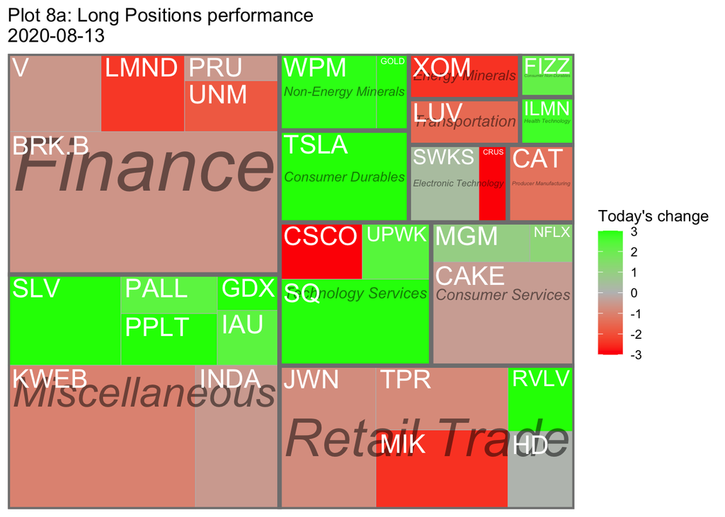

Short postions

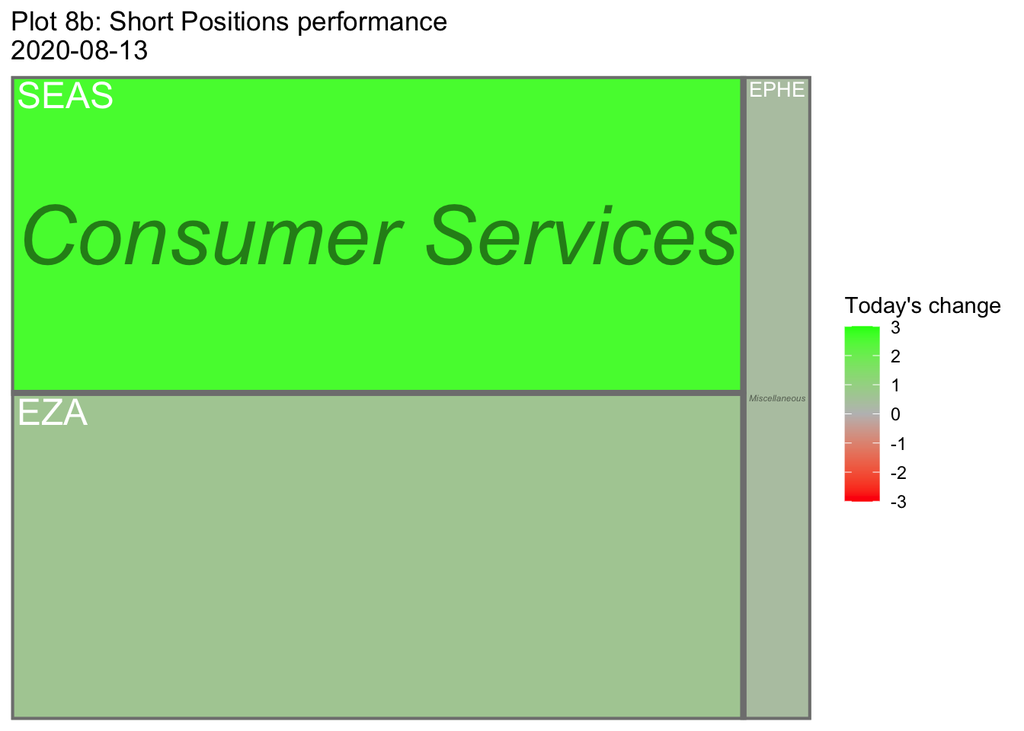

S&P 500 stocks colored by last day performance.

Outliers skew the colors, making the other stocks look pale. I restricted the colors to max of 3 and -3% change. Every stock having higher or lower than 3% change has the same color.

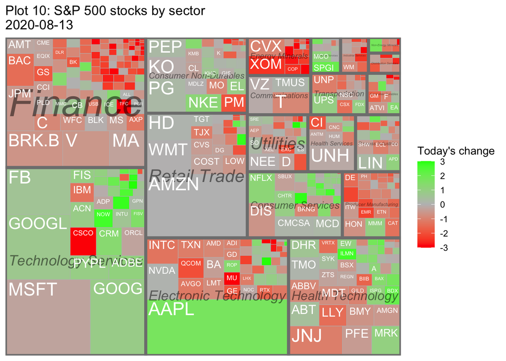

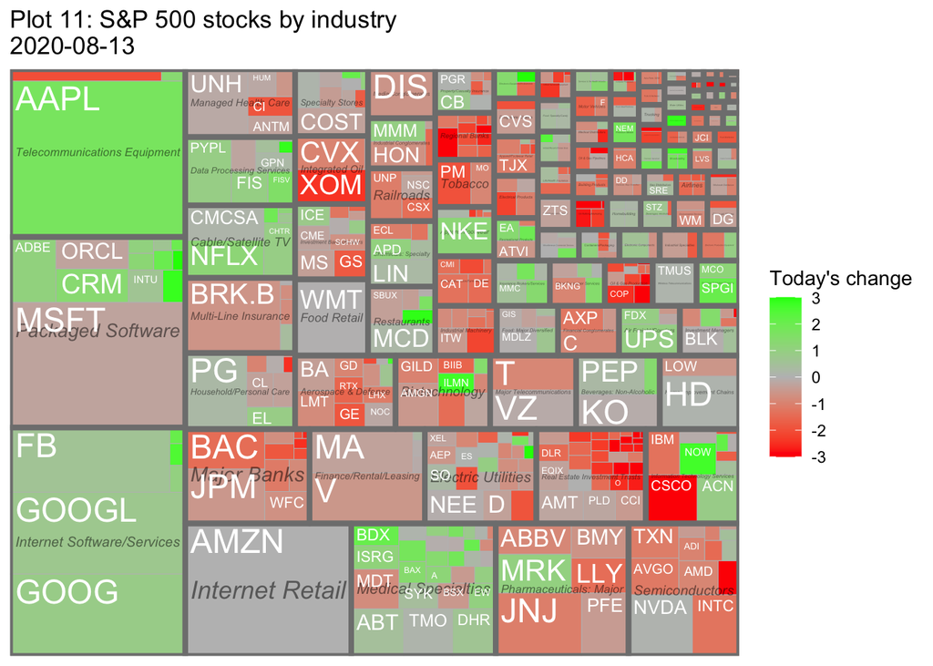